# afgifte_gwr

*Disclaimer: As of late-April 2021, the purpose of this notebook is **not** to produce publishable results, but to do a 'test run' of our analysis methods on a very rough, very imperfect dataset. As you will see in the notebook, the models created are highly inaccurate and unusable - this is understandable and expected because we haven't refined our dataset yet. Nevertheless, I still 'interpreted' the results as if they were significant, just to get a sense of how we would interpret the refined dataset in the future.*

*In the upcoming weeks, we will do the following to refine our dataset:*

- *categorize material flows by material type (using GNC) and/or industry type (using SBI codes).*
- *incorporate more explanatory variables that could have an effect on manufacturing activity. This would involve re-examining literature, as well as looking for more datasets that could represent these explanatory variables.*

# Geographically weighted regression (GWR)

Now that we have established that there are geographical patterns to the afgifte data (see afgifte_esda), the next step is to ask why these patterns exist. We can do this with generalized linear regression (GLR) and geographically weighted regression (GWR).

**Generalized linear regression** (GLR) explains how independent variables (e.g. average income, proximity to infrastructure, land value) affect a dependent variable (in our case, log(kg) of secondary resources received per postcode) using a formula. The formula describes whether the independent variables are correlated to the dependent variable, and how. **Geographically weighted regression** (GWR) is similar to linear regression, but instead of having one formula describing the entire dataset, you have **one formula for each postcode** (so that's 4000 formulas describing 4000 postcodes), describing relationships between variables within its neighborhood. This allows us to find out how strongly variables affect postcodes in different areas.

In this notebook, I would like to make a first attempt at conducting GWR analysis on the afgifte dataset. The dependent variable will be log(kg) of secondary resources received for each pc4 postcode area, and the indenpendent variables will come from the CBS dataset, and include variales like average land value, income, population, proximity to universities...etc. I don't expect to get an accurate model, or any significant results (I need more independent variable for that), but at least I can get a first understanding of how we would conduct GWR on our dataset.

This notebook will be separated into four parts: importing our independent variable from CBS data, generalized linear regression, geographically weighted regression, and exploring local bivariate relationships.

Handy links:

- pySAL/mgwr
  - https://mehak-sachdeva.github.io/MGWR_workshop_book/
  - https://github.com/pysal/mgwr
  - https://www.youtube.com/watch?v=o8lDAJaFZfU&t=4456s&ab_channel=UnivConsortiumGeographicInformationScience
- ESRI
  - https://www.youtube.com/watch?v=ob18SuuAJGI&t=1416s&ab_channel=EsriEvents

```python
# import modules, change cwd
import os
import pandas as pd
import geopandas as gpd
import numpy as np
import matplotlib.pyplot as plt
import feather
import plotly.express as px
import psutil
import seaborn as sn
%matplotlib inline
```

```python
os.chdir('..')
os.chdir('data')
os.getcwd()
```

```
'C:\\Users\\tpytsui\\Documents\\Surfdrive\\Documents\\_PhD\\_github\\lma_circular-maker-city\\data'
```

## Preparing dataframe for analysis

Here we create a csv file that can be fed into the gwr tool. The dataframe will include the columns log(kg), postcode, coordinates, and relevant variables for the CBS dataset. I took the CBS dataset for PC4 from 2018, which is the most recent dataset that is complete. For the afgifte dataset, I only looked at numbers from 2019. I'm still unsure of how to deal with postcodes receiving 0kg of secondary materials - for now, I've included them in the analysis.

Relevant columns (see detailed explanations on [CBS website](https://www.cbs.nl/nl-nl/longread/diversen/2021/statistische-gegevens-per-vierkant-en-postcode-2020-2019-2018/4-beschrijving-cijfers)):

- PC4 - postcode
- INWONER - num residents
- AANTAL_HH - num households
- GEM_HH_GR - av. household size
- WONING - num houses
- WOZWONING - av. household price
- M_INKHH - median income per household
- P_LINK_HH - % low income households
- P_HINK_HH - % high income households
- AFS_OPRIT - km to main road access ramp
- AFS_TRNOVS - km to nearest major interchange station
- AFS_TREINS - km to nearest train station
- AFS_ONDHV - km to nearest havo/vwo
- AV10_ONDHV - num havo/vwo within 10km
- AFS_ONDVMB - km to nearest vmbo
- AV10ONDVMB - num vmbo within 10km
- OAD - num addresses per km2
- STED - urbanity code (1=very urban, 5=non-urban)
- geometry

```python
# import CBS pc4 dataset
cbs = gpd.read_file('variables/CBS/CBS-PC4-2018-v3/CBS_PC4_2018_v3.shp')

# select and rename columns
cbs = cbs[['PC4', 'INWONER', 'AANTAL_HH', 'GEM_HH_GR', 'WONING', 'M_INKHH','P_LINK_HH', 'P_HINK_HH',
           'AFS_OPRIT', 'AFS_TRNOVS', 'AFS_TREINS',
           'AFS_ONDHV', 'AV10_ONDHV', 'AFS_ONDVMB', 'AV10ONDVMB', 'OAD', 'STED']]
cbs.rename(columns={
    'PC4': 'pc4',
    'INWONER': 'pop',
    'AANTAL_HH': 'numHh',
    'GEM_HH_GR': 'avHhSize',
    'WONING': 'numDwellings',
    'M_INKHH': 'medHhIncome',
    'P_LINK_HH': 'perLowIncome',
    'P_HINK_HH': 'perHighIncome',
    'AFS_OPRIT': 'kmMainRoad',
    'AFS_TRNOVS': 'kmMainTrain',
    'AFS_TREINS': 'kmTrain',
    'AFS_ONDHV': 'kmHavo',
    'AV10_ONDHV': '10kmHavo',
    'AFS_ONDVMB': 'kmVmbo',
    'AV10ONDVMB': '10kmVmbo',
    'OAD': 'addressesPerKm2',
    'STED': 'urbanCode'
}, inplace=True)

# replace numbers like -99999 to np.NaN
def to_nan(x):
    if x < 0:
        return np.NaN
    else:
        return x
columns = ['pop', 'numHh', 'avHhSize', 'numDwellings',
       'perLowIncome', 'perHighIncome', 'kmMainRoad', 'kmMainTrain', 'kmTrain',
       'kmHavo', '10kmHavo', 'kmVmbo', '10kmVmbo', 'addressesPerKm2',
       'urbanCode']
for column in columns:
    cbs[column] = cbs[column].map(lambda x: to_nan(x))
```

```python
# create df with columns: pc4, log(kg), cbs variables for each pc4
# read afgifte dataframe
df = feather.read_dataframe('lma/af_2019-2020_matched-codes.feather')
df = df[~df.gnc.isna()] # extract rows with gnc
df.eaPostcode = df.eaPostcode.str[:4] # convert to pc4
df = df[df.year == 2019] # only looking at numbers in 2019
df = df.groupby(['eaPostcode']).sum().kg.reset_index()
df.rename(columns={'eaPostcode': 'postcode', 'kg': 'kg_received'}, inplace=True)
df.postcode = df.postcode.astype('int64')

# create column with log kg values
def log(x):
    if x > 0:
        return np.log(x)
    else:
        return 0
df['log_kg'] = df.kg_received.map(lambda x: log(x))
print('afgifte rows, columns: {}'.format(df.shape))
print('cbs rows, columns: {}'.format(cbs.shape))

# merge with cbs data (which already has geometry)
df = pd.merge(df, cbs, how='right', left_on='postcode', right_on='pc4')
df.drop(labels=['postcode'], axis=1, inplace=True)
df['kg_received'] = df['kg_received'].fillna(0)
df['log_kg'] = df['log_kg'].fillna(0)
df = df[['pc4','kg_received', 'log_kg', 'pop', 'numHh', 'avHhSize',
       'numDwellings', 'medHhIncome', 'perLowIncome', 'perHighIncome',
       'kmMainRoad', 'kmMainTrain', 'kmTrain', 'kmHavo', '10kmHavo', 'kmVmbo',
       '10kmVmbo', 'addressesPerKm2', 'urbanCode']] # rearrange pc4 in front, drop kg_received

# display shape
print('merged (cbs+lma) rows, columns: {}'.format(df.shape))

# add geometry of postcodes to df
nl_pc4 = gpd.read_file('spatial-data/nl_pc4.shp')
nl_pc4 = nl_pc4[['PC4', 'geometry']]
nl_pc4.PC4 = nl_pc4.PC4.astype('int64')
print('nl_pc4 rows, columns: {}'.format(nl_pc4.shape))
df = pd.merge(df, nl_pc4, how='left', left_on='pc4', right_on='PC4')

# get centroids, x, y coordinates
df = gpd.GeoDataFrame(df)
df = df.to_crs('EPSG:28992')
df['centroids'] = df.geometry.centroid
df['x'] = df.centroids.x
df['y'] = df.centroids.y
print('merged (cbs+lma+nl_pc4) rows, columns: {}'.format(df.shape))

df.head(2)
```

```
afgifte rows, columns: (2155, 3)
cbs rows, columns: (4066, 17)
merged (cbs+lma) rows, columns: (4066, 19)
nl_pc4 rows, columns: (4068, 2)
merged (cbs+lma+nl_pc4) rows, columns: (4066, 24)
```

|  | pc4 | kg_received | log_kg | pop | numHh | avHhSize | numDwellings | medHhIncome | perLowIncome | perHighIncome | ... | 10kmHavo | kmVmbo | 10kmVmbo | addressesPerKm2 | urbanCode | PC4 | geometry | centroids | x | y |
| --- | --- | --- | --- | --- | --- | --- | --- | --- | --- | --- | --- | --- | --- | --- | --- | --- | --- | --- | --- | --- | --- |
| 0 | 1119 | 0.0 | 0.000000 | 10.0 | 10.0 | 1.0 | NaN | onclassificeerbaar | NaN | NaN | ... | 6.0 | 3.1 | 12.0 | 373.0 | 5.0 | 1119 | POLYGON ((113159.264 478004.579, 113152.471 47... | POINT (112224.625 477313.339) | 112224.625439 | 477313.339233 |
| 1 | 1454 | 2309980.0 | 14.652749 | 420.0 | 180.0 | 2.3 | 185.0 | 60-80 boven midden | 25.4 | 36.5 | ... | 10.2 | 5.3 | 13.0 | 58.0 | 5.0 | 1454 | POLYGON ((126799.810 494710.458, 126793.718 49... | POINT (126012.045 494315.221) | 126012.045367 | 494315.220710 |

2 rows × 24 columns

```python
# save as csv for mgwr tool
df_0 = df[df.log_kg > 0]
df_0.to_csv('lma/af_2019_no0_for-GWR.csv')

df.to_csv('lma/af_2019_for-GWR.csv')
```

## Exploratory regression

Before doing a regression analysis, we need to choose the right explanatory variables. In other words, we need to choose variables that will more likely have a significant effect on our dependent variable, log(kg). We can choose variables by reading existing literature (we've made a start with our [previous paper](https://www.mdpi.com/2071-1050/13/1/23/htm)), but we can also do this using tools. One of these tools is the exploratory regression tool developed by ArcGIS. This tool finds a combination of explanatory variables that best explains the dependent variable. It does this by first finding the best variable, then the best combination of two variables, then three variables...and so on, until a passing model is found. Each iteration is evaluated using a number a statistical tests - AICc, VIF, JB, and R2.

Explanation of the statistical tests:

- **Akaike information criterion** (AIC): The Akaike information criterion (AIC) is an estimator of prediction error and thereby relative quality of statistical models for a given set of data. Given a collection of models for the data, AIC estimates the quality of each model, relative to each of the other models. Thus, AIC provides a means for model selection. The lower the number, the better the model.
- **Variance inflation factor** (VIF): The Variation inflation factor (VIF) checks for redundant variables in a regression model. In other words, it checks if multiple variables have the same effect on the model. As a rule of thumb, a model with a VIF of 7.5 or lower is considered acceptable.
- **Jarque-Bera test** (JB): The Jarque-Bera test checks whether data is normally distributed (follows a bell-shape curve). For exploratory regression, this test is applied to the errors of a model to see if errors are normally distributed. If the JB is far from zero, it signals that the errors are **not** normally distributed, and that the model is inaccurate.
- **Coefficient of determination** (R2, pronounced R-squared): The coefficient of determination (usually called r-squared) shows how accurate a model is, or in other words, how well the formula explains the data. The r2 number can be interpreted as a percentage - for example, a model with an r2 of 0.86 explains 86% of data variability. As a rule of thumb, models with an r2 > 0.8 are deemed as passing.

I haven't done this step yet.

## Generalized linear regression

Generalized linear regression (GLR) explains how independent variables (e.g. average income, proximity to infrastructure, land value) affect a dependent variable (in our case, log(kg) of secondary resources received per postcode) using a formula (also called a model). The model describes whether the independent variables are correlated to the dependent variable, and how. The accuracy of the model can be checked with the following methods:

- check if errors are spatially clustered (check visually, then spatial auto-correlation (global moran's I))
- check if errors are normall distributed using Jarque-Bera statistic (not significant)
- check for redundant variables with variable inflation factor (< 7.5, lower the better)
- when comparing models: Akaike's Information Criterion (AICc), lower the better
- check adjusted r2, higher the better (e.g. 0.86 = model explains 86% of data variability)

Using the mgwr tool created by Arizona State University (recommended by Bardia), we created a GLR model for our data. You can see a summary below.

```python
# generalized linear regression
f = open('../gwr/afgifte_gwr_results-summary_summary_GLR.txt')
print(f.read())
```

```
================================================================================
MGWR Version: 2.2.1
Released on: 03/20/2020
Source code is available at: https://github.com/pysal/mgwr
Development Team: Ziqi Li, Taylor Oshan, Stewart Fotheringham, Wei Kang,
Levi Wolf, Hanchen Yu, Mehak Sachdeva, and Sarah Bardin
Spatial Analysis Research Center (SPARC)
Arizona State University, Tempe, USA
================================================================================
Model type:                                                             Gaussian
Number of observations:                                                     3558
Number of covariates:                                                         13
Dependent variable:                                                       log_kg
Variable standardization:                                                     On
Total runtime:                                                           0:00:27

Global Regression Results
--------------------------------------------------------------------------------
Residual sum of squares:                                                3241.968
Log-likelihood:                                                        -4883.104
AIC:                                                                    9792.208
AICc:                                                                   9794.326
R2:                                                                        0.089
Adj. R2:                                                                   0.086

Variable                                   Est.         SE  t(Est/SE)    p-value
------------------------------------ ---------- ---------- ---------- ----------
Intercept                                -0.000      0.016     -0.000      1.000
10kmVmbo                                  0.034      0.057      0.607      0.544
numHh                                    -0.444      0.140     -3.163      0.002
avHhSize                                  0.061      0.028      2.186      0.029
numDwellings                              0.626      0.137      4.559      0.000
perLowIncome                             -0.022      0.041     -0.524      0.601
perHighIncome                             0.017      0.035      0.478      0.633
kmMainRoad                               -0.088      0.018     -4.980      0.000
kmMainTrain                               0.092      0.024      3.900      0.000
kmTrain                                  -0.119      0.022     -5.404      0.000
kmHavo                                    0.130      0.026      4.928      0.000
10kmHavo                                 -0.184      0.058     -3.149      0.002
kmVmbo                                    0.071      0.025      2.818      0.005

================================================================================
Acknowledgement:
We acknowledge the support of the National Science Foundation under Award 1758786
from the Geography and Spatial Sciences Program to A. S. Fotheringham which
enabled this software to be written and made freely available.
================================================================================
```

## Geographically weighted regression

While generalized linear regression (GLR) explains the relationship between a dependent variable (log(kg)) and explanatory variables using **one formula for the whole dataset** (in our case, the whole of the Netherlands), geographically weighted regression does the same by using **one formula for every single datapoint** (in our case, that's every single postcode area). This means that, with gwr, we get 4000 formulas (aka models) for 4000 postcodes. How is this done?

- First, the tool defines the 'bandwidth', which is the size of a 'neighborhood'. Here, we are asking the question, at which spatial scale do our explanatory variables affect the log(kg)? Do these processes happen at a national, provincial, municipal, or neighborhood scale? GWR assumes that all explanatory variables function at the same scale. The bandwidth can be defined using an algorithm called the 'golden section', which basically ping-pongs between random numbers until it finds the bandwidth that produces the model with the best AICc score.
- Once the bandwidth is defined, the tool calculates a formula for each postcode. Let's say the bandwidth is a radius of 10km. This is what the tool does:
  - find all postcodes within a 10km radius of postcode A - this is the local neighborhood of postcode A (local neighborhood A).
  - calculate a formula that describes the relationship between the variables in local neighborhood A.
  - attribute that formula to postcode A.
  - this process is repeated for postcode B, C, D...until all 4000 postcodes have gone through it.

The result of the gwr is 4000 formulas that describe the local condition of 4000 postcodes. But why is this necessary? Why not just use one formula to describe the whole of the Netherlands using GLR? What GWR can tell us (and GLR can't) is how strongly an explanatory variable affects the dependent variable in different geographical areas of the dataset. For example, the number of households may have a bigger effect on log(kg) in the north of the Netherlands than the south.

GWR was conducted using the MGWR tool (using its GUI instead of code directly), and resulted in a summary txt file and detailed csv file, which shows the results of the GWR. A summary of the GWR results can be seen below.

```python
# summary text for GWR
f = open('../gwr/afgifte_gwr_results-summary_summary_GWR.txt')
print(f.read())
```

```
Model type:                                                             Gaussian
Number of observations:                                                     3558
Number of covariates:                                                         13
Dependent variable:                                                       log_kg
Variable standardization:                                                     On
Total runtime:                                                           0:00:27

Geographically Weighted Regression (GWR) Results
--------------------------------------------------------------------------------
Coordinates type:                                                      Projected
Spatial kernel:                                                Adaptive bisquare
Criterion for optimal bandwidth:                                            AICc
Bandwidth used:                                                          650.000

Diagnostic Information
--------------------------------------------------------------------------------
Residual sum of squares:                                                2803.336
Effective number of parameters (trace(S)):                               166.052
Degree of freedom (n - trace(S)):                                       3391.948
Sigma estimate:                                                            0.909
Log-likelihood:                                                        -4624.490
Degree of Dependency (DoD):                                                0.688
AIC:                                                                    9583.085
AICc:                                                                   9599.648
BIC:                                                                   10614.961
R2:                                                                        0.212
Adj. R2:                                                                   0.174
Adj. alpha (95%):                                                          0.004
Adj. critical t value (95%):                                               2.887

Summary Statistics For GWR Parameter Estimates
--------------------------------------------------------------------------------
Variable                        Mean        STD        Min     Median        Max
--------------------      ---------- ---------- ---------- ---------- ----------
Intercept                      0.054      0.217     -0.652      0.059      0.618
10kmVmbo                       0.186      0.370     -0.871      0.205      1.449
numHh                         -0.631      0.532     -3.065     -0.579      0.888
avHhSize                       0.035      0.113     -0.296      0.040      0.315
numDwellings                   0.848      0.500     -0.371      0.818      3.085
perLowIncome                  -0.030      0.163     -0.415     -0.006      0.366
perHighIncome                  0.026      0.153     -0.313      0.038      0.396
kmMainRoad                    -0.120      0.073     -0.246     -0.126      0.075
kmMainTrain                    0.100      0.093     -0.154      0.116      0.315
kmTrain                       -0.051      0.121     -0.391     -0.035      0.218
kmHavo                         0.109      0.125     -0.205      0.105      0.462
10kmHavo                      -0.307      0.390     -1.482     -0.336      0.763
kmVmbo                         0.126      0.119     -0.110      0.095      0.565
```

Interpretation of GWR summary above:

- The GWR model has an **adjusted R2 (Adj R2) of 0.174**. This means our model explains 17% of the data variability. Again, this is nowhere near 0.8 (80%), but it's higher than the GLR model from our previous step, which was 0.086 (8.6%).
- The **summary statistics for GWR parameter estimates** shows the coefficients for each explanatory variable. For GWR, instead of having one coefficient for each explanatory variable, we have 4000 coefficients for each explanatory variable describing 4000 local neighborhoods of 4000 postcodes. The 'mean' column shows the average of the 4000 coefficients for each variable.
- The GWR model has an **adjusted critical t value of 2.887**. This means that coefficients (or parameter estimates) with t-values that are between -2.887 and 2.887 are probably insignificant, just noise.

#### Diving deeper...

We can dive deeper into the GWR results by studying the resulting csv file. The csv file has the following columns that are relevant to us:

- ols_residual - Residuals (error) from OLS model for every location point
- gwr_yhat - yhat from MGWR for each location point
- gwr_residual - Residuals (error) from MGWR for every location point
- localR2 - Explained variation at each location point
- beta_ - Columns starting with beta are parameter estimates for the covariates )
- se_ - Columns starting with se are standard errors for estimates for the covariates
- t_ - Columns starting with t are t values for estimates for the covariates
- p_ - Columns starting with p are p values for estimates for the covariates
- sumW_ - Sum of weights for the covariates at each location

```python
# turn gwr csv into geodataframe by merging with shpfile of nl_pc4
results = pd.read_csv('../gwr/afgifte_gwr_results-summary_results.csv')
results.pc4 = results.pc4.astype('int64')
print('gwr results rows, columns: {}'.format(results.shape))
results = pd.merge(nl_pc4, results, how='left', left_on='PC4', right_on='pc4')
results.dropna(inplace=True)
print('geo-coded results rows, columns: {}'.format(results.shape))
results = gpd.GeoDataFrame(results)
# note: not sure why there are only 3558 rows, it should be ~4000.
```

```
gwr results rows, columns: (3558, 63)
geo-coded results rows, columns: (3558, 65)
```

#### T-values

First, let's take a look at which variables contain significant coefficients. In other words, which variables have t-values lower than -2.887 or higher than 2.887? (2.887 = critical t-value) From the results below, we can see that all explanatory variables contain significant coefficients, but none of the variables have mean t-values that are significant.

```python
t = results[['t_Intercept', 't_10kmVmbo', 't_numHh', 't_avHhSize', 't_numDwellings', 't_perLowIncome',
       't_perHighIncome', 't_kmMainRoad', 't_kmMainTrain', 't_kmTrain',
       't_kmHavo', 't_10kmHavo', 't_kmVmbo']]

t.describe()
```

|  | t_Intercept | t_10kmVmbo | t_numHh | t_avHhSize | t_numDwellings | t_perLowIncome | t_perHighIncome | t_kmMainRoad | t_kmMainTrain | t_kmTrain | t_kmHavo | t_10kmHavo | t_kmVmbo |
| --- | --- | --- | --- | --- | --- | --- | --- | --- | --- | --- | --- | --- | --- |
| count | 3558.000000 | 3558.000000 | 3558.000000 | 3558.000000 | 3558.000000 | 3558.000000 | 3558.000000 | 3558.000000 | 3558.000000 | 3558.000000 | 3558.000000 | 3558.000000 | 3558.000000 |
| mean | 0.582637 | 0.728709 | -1.330248 | 0.410966 | 1.842449 | -0.284386 | 0.203620 | -1.509528 | 1.115817 | -0.711250 | 1.109642 | -1.130149 | 1.267348 |
| std | 2.756136 | 1.375188 | 1.059716 | 1.328957 | 1.031482 | 1.288258 | 1.342538 | 0.864598 | 1.097597 | 1.437424 | 1.162513 | 1.492826 | 1.015101 |
| min | -6.433437 | -2.567790 | -4.731355 | -3.614789 | -0.556431 | -3.325182 | -2.845114 | -2.932017 | -1.348348 | -4.279874 | -1.540569 | -4.155725 | -0.829331 |
| 25% | -1.562370 | -0.265458 | -1.908155 | -0.525823 | 1.392213 | -0.870106 | -0.503622 | -2.218607 | 0.273055 | -1.692782 | 0.275188 | -2.096918 | 0.625973 |
| 50% | 0.729681 | 0.725483 | -1.247293 | 0.478442 | 1.769614 | -0.049973 | 0.343900 | -1.646953 | 1.236015 | -0.345109 | 1.006520 | -1.204316 | 1.019611 |
| 75% | 2.753560 | 1.569214 | -0.758464 | 1.405315 | 2.258826 | 0.558299 | 1.101926 | -0.988894 | 1.857684 | 0.320580 | 1.982698 | -0.047441 | 1.855047 |
| max | 6.309569 | 3.492052 | 0.857751 | 3.317609 | 5.393568 | 2.389697 | 3.093828 | 1.045853 | 3.757149 | 2.637318 | 3.786896 | 2.412992 | 4.777259 |

#### P-values

Now let's take a look at the p-values. Which variables have significant p-values (where p < 0.05)? Similar to the t-values, we can see that, while all variables contain postcodes with p-values < 0.05, none of the average p-values are lower than 0.05. Variable with relatively lower average p-values are: numDwellings, kmMainRoad, and 10kmHavo.

```python
p = results[['p_Intercept', 'p_10kmVmbo', 'p_numHh', 'p_avHhSize', 'p_numDwellings', 'p_perLowIncome',
       'p_perHighIncome', 'p_kmMainRoad', 'p_kmMainTrain', 'p_kmTrain',
       'p_kmHavo', 'p_10kmHavo', 'p_kmVmbo']]
p.describe()
```

|  | p_Intercept | p_10kmVmbo | p_numHh | p_avHhSize | p_numDwellings | p_perLowIncome | p_perHighIncome | p_kmMainRoad | p_kmMainTrain | p_kmTrain | p_kmHavo | p_10kmHavo | p_kmVmbo |
| --- | --- | --- | --- | --- | --- | --- | --- | --- | --- | --- | --- | --- | --- |
| count | 3.558000e+03 | 3558.000000 | 3558.000000 | 3558.000000 | 3.558000e+03 | 3558.000000 | 3558.000000 | 3558.000000 | 3558.000000 | 3558.000000 | 3558.000000 | 3558.000000 | 3558.000000 |
| mean | 1.723124e-01 | 0.348337 | 0.285882 | 0.381564 | 1.650030e-01 | 0.451894 | 0.404814 | 0.220774 | 0.323273 | 0.445565 | 0.354549 | 0.271989 | 0.334057 |
| std | 2.492512e-01 | 0.288304 | 0.267440 | 0.294422 | 2.308249e-01 | 0.315564 | 0.317913 | 0.259045 | 0.301927 | 0.332972 | 0.318652 | 0.287329 | 0.276614 |
| min | 1.413892e-10 | 0.000485 | 0.000002 | 0.000305 | 7.357632e-08 | 0.000893 | 0.001991 | 0.003389 | 0.000175 | 0.000019 | 0.000155 | 0.000033 | 0.000002 |
| 25% | 1.187640e-03 | 0.084000 | 0.056452 | 0.123837 | 2.395461e-02 | 0.138589 | 0.099606 | 0.026576 | 0.063297 | 0.060631 | 0.047478 | 0.035228 | 0.063672 |
| 50% | 3.558487e-02 | 0.295910 | 0.212372 | 0.331419 | 7.687708e-02 | 0.466385 | 0.357804 | 0.099656 | 0.214439 | 0.469585 | 0.269446 | 0.159208 | 0.307982 |
| 75% | 2.716545e-01 | 0.553845 | 0.437834 | 0.620297 | 1.639452e-01 | 0.728392 | 0.680841 | 0.321947 | 0.556027 | 0.738343 | 0.632182 | 0.420786 | 0.528477 |
| max | 9.994903e-01 | 0.999482 | 0.999154 | 0.999884 | 9.976427e-01 | 0.999126 | 0.999869 | 0.999521 | 0.998975 | 0.999343 | 0.999447 | 0.999832 | 0.999745 |

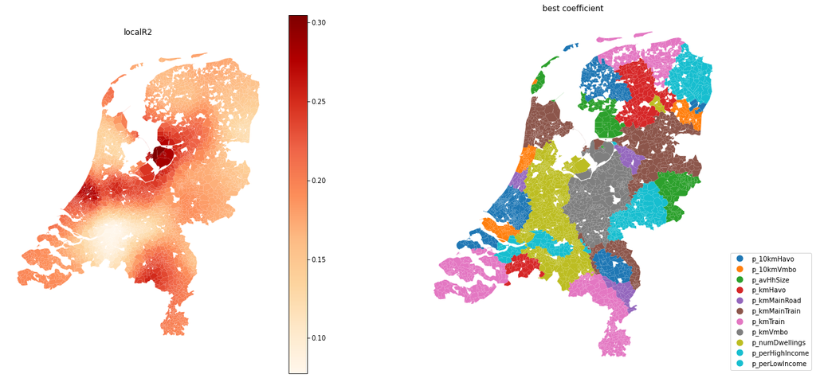

```python
fig, ax = plt.subplots(1,2,figsize=(20,10))
from mpl_toolkits.axes_grid1 import make_axes_locatable

# local R2
results.plot(column='localR2', ax=ax[0], cmap='OrRd', legend=True)
ax[0].axis('off')
ax[0].set_title('localR2')

# best coefficient
pPlot = results[['p_10kmVmbo', 'p_numHh', 'p_avHhSize', 'p_numDwellings', 'p_perLowIncome',
       'p_perHighIncome', 'p_kmMainRoad', 'p_kmMainTrain', 'p_kmTrain',
       'p_kmHavo', 'p_10kmHavo', 'p_kmVmbo']]
pPlot['minP'] = pPlot.apply(lambda row: row.idxmin(), axis=1)
geo = results[['PC4', 'geometry']]
pPlot = pd.concat([geo, pPlot], axis=1)
pPlot.plot(column='minP', ax=ax[1], legend=True, legend_kwds={'loc': 'lower left', 'bbox_to_anchor':(1,0)})
ax[1].axis('off')
ax[1].set_title('best coefficient')

plt.show()
```

*Disclaimer: as of 22-April-2021, these are **not publishable results**, because the gwr model we created is **highly inaccurate**. These maps and their explanations only show what results and interpretations to expect when we input a more refined dataset in the upcoming weeks.*

## Local bivariate relationships

From the GWR results, we can also understand how a coefficient of *one* variable changes aross the country. This allows us to understand how the influence of each explanatory variable on the dependent variable changes across space. For example, the number of households could have a stronger influence on log(kg) in the north of the country, while a weaker influence on the south. Sometimes, the coefficient can even have different signs - postive in some areas, while negative in others. The maps below show the value of coefficients for numDwellings, kmMainRoad, and 10kmHavo for each postcode.

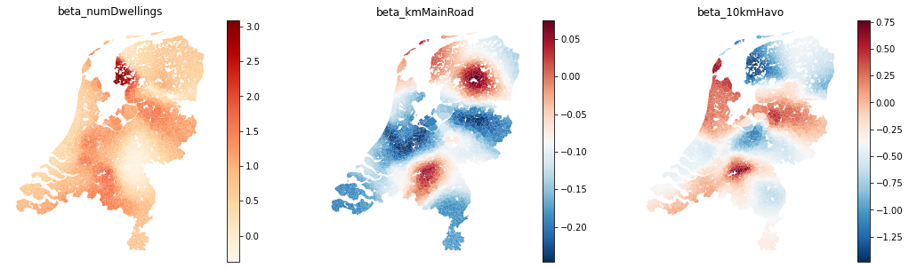

```python
toPlot = ['beta_numDwellings', 'beta_kmMainRoad', 'beta_10kmHavo']

fig, ax = plt.subplots(1,3,figsize=(6*3,5))
from mpl_toolkits.axes_grid1 import make_axes_locatable

# beta_numDwellings
results.plot(column=toPlot[0], ax=ax[0], cmap='OrRd', legend=True)
ax[0].axis('off')
ax[0].set_title(toPlot[0])

# beta_kmMainRoad
results.plot(column=toPlot[1], ax=ax[1], cmap='RdBu_r', legend=True)
ax[1].axis('off')
ax[1].set_title(toPlot[1])

# beta_10kmHavo
results.plot(column=toPlot[2], ax=ax[2], cmap='RdBu_r', legend=True)
ax[2].axis('off')
ax[2].set_title(toPlot[2])

plt.show()
```

## *Statistically significant* local bivariate relationships

A caveat of the maps above show the coefficients of *all* postcodes, even if those coefficients are not statistically significant. If we interpret these maps, we could end up identifying relationships that were merely caused by statistical noise. To ensure that our interpretation is accurate, we should filter out all coefficients that are insignificant. We do this by looking again at the critical t-value from the gwr results summary: 2.887. So for us, we should only be mapping postcodes with coefficients with a t-value that are either > 2.887 or < -2.887.

We will first try this out for beta_numDwellings. We we're trying to do here is to select coefficients (beta_numDwellings) that have a t-value (t_numDwellings) that are either > 2.887 or < -2.887.

```python
results[['beta_numDwellings', 't_numDwellings']].head(3)
```

|  | beta_numDwellings | t_numDwellings |
| --- | --- | --- |
| 0 | 0.965478 | 2.631035 |
| 1 | 0.941104 | 2.565641 |
| 2 | 0.848063 | 2.240564 |

```
percentage of postcodes with significant results: 13.63
```

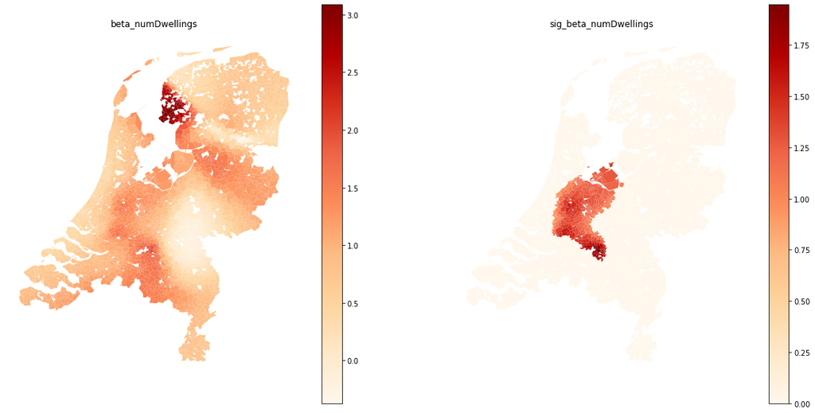

```python
# set critical t-value (see gwr summary.txt)
t = 2.887

# extract significant beta_numDwellings
def sig(row):
    if row.t_numDwellings > t or row.t_numDwellings < -t:
        return row.beta_numDwellings
    else:
        return 0
results['sig_beta_numDwellings'] = results.apply(lambda row: sig(row), axis=1)
numSig = len(results[results.sig_beta_numDwellings > 0])

# plot
fig, ax = plt.subplots(1,2,figsize=(20,10))

# beta_numDwellings
results.plot(column='beta_numDwellings', ax=ax[0], cmap='OrRd', legend=True)
ax[0].axis('off')
ax[0].set_title('beta_numDwellings')

# sig_beta_numDwellings
results.plot(column='sig_beta_numDwellings', ax=ax[1], cmap='OrRd', legend=True)
ax[1].axis('off')
ax[1].set_title('sig_beta_numDwellings')

# display
print('percentage of postcodes with significant results: {}'.format(round(numSig / len(results) * 100,2)))
plt.show()
```

Now we can try it for all three variables - numDwellings, kmMainRoad, and 10kmHavo

```python
# set critical t-value (see gwr summary.txt)
t = 2.887
t_ = ['t_numDwellings', 't_kmMainRoad', 't_10kmHavo']
b_ = ['beta_numDwellings', 'beta_kmMainRoad', 'beta_10kmHavo']
sb_ = ['sig_beta_numDwellings', 'sig_beta_kmMainRoad', 'sig_beta_10kmHavo']

for i in range(3):
    def sig(row):
        if row[t_[i]] > t or row[t_[i]] < -t:
            return row[b_[i]]
        else:
            return 0
    results[sb_[i]] = results.apply(lambda row: sig(row), axis=1)
    numSig = len(results[results[sb_[i]] > 0])
    print('percentage of postcodes with significant results for {}: {}'.format(b_[i], round(numSig / len(results) * 100,2)))

# # plot
# fig, ax = plt.subplots(1,2,figsize=(20,10))

# # beta_numDwellings
# results.plot(column='beta_numDwellings', ax=ax[0], cmap='OrRd', legend=True)
# ax[0].axis('off')
# ax[0].set_title('beta_numDwellings')

# # sig_beta_numDwellings
# results.plot(column='sig_beta_numDwellings', ax=ax[1], cmap='OrRd', legend=True)
# ax[1].axis('off')
# ax[1].set_title('sig_beta_numDwellings')

# # display
# plt.show()
```

```
percentage of postcodes with significant results for beta_numDwellings: 13.63
percentage of postcodes with significant results for beta_kmMainRoad: 0.0
percentage of postcodes with significant results for beta_10kmHavo: 0.0
```